# Анализ закономерностей определяющих успешность компьютерной игры.

## Портрет пользователя каждого региона

Определим для 3х регионов (NA, EU, JP) самые популярные платформы (топ-5).

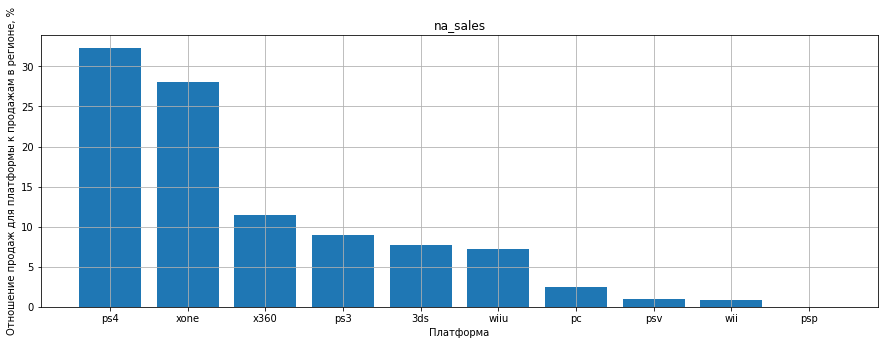

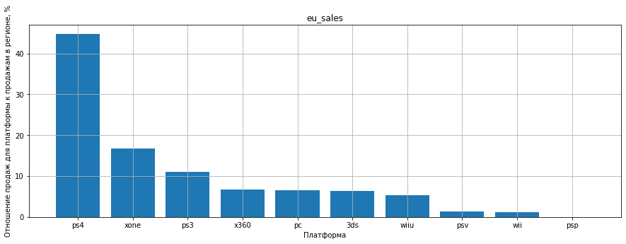

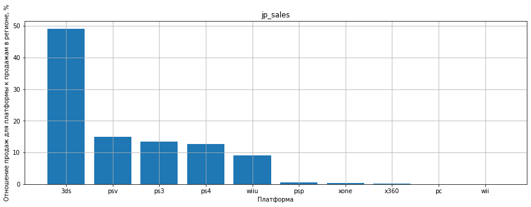

```python
for i in ['na_sales', 'eu_sales', 'jp_sales']:
    plt.figure(figsize=(15, 5))
    plt.bar(reg_sales(df1, i, 'platform')['platform'], reg_sales(df1, i, 'platform')['sale_ratio'])
    plt.grid()
    plt.xlabel('Платформа')
    plt.ylabel('Отношение продаж для платформы к продажам в регионе, %')
    plt.title(i)

    plt.show()
```

Итак в трех регионах есть как схожие лидеры ps4, xone, x360, ps3, 3ds, wiiu, так и уникальные (pc и psv). Выберем платформы ps4, ps3, xone, x360, 3ds, wiiu, pc, psv и other и построим круговую диаграмму.

```python
df1=df1.copy()
```

```python
df1['na_top_platf']= list(map(lambda x: 'other' if x not in ['ps4', 'ps3', 'xone', 'x360', 'wiiu'] else x, df1['platform']))
```

```python
df1['eu_top_platf']= list(map(lambda x: 'other' if x not in ['ps4', 'ps3', 'xone', 'x360', 'pc'] else x, df1['platform']))
```

```python
df1['jp_top_platf']= list(map(lambda x: 'other' if x not in ['ps4', 'ps3', '3ds', 'psv', 'wiiu'] else x, df1['platform']))
```

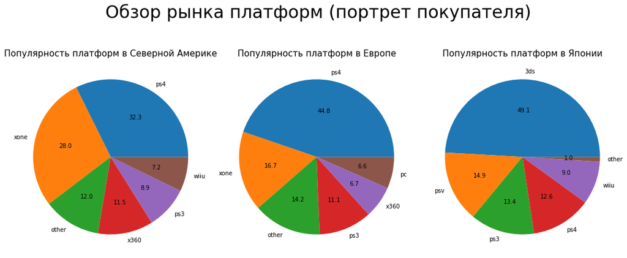

```python
plt.figure(figsize=(15, 7))

ax1 = plt.subplot(1, 3, 1)
ax1.pie(reg_sales(df1, 'na_sales', 'na_top_platf')['sale_ratio'], labels=reg_sales(df1, 'na_sales',
                                                                'na_top_platf')['na_top_platf'], autopct='%.1f');
ax1.set_title('Популярность платформ в Северной Америке', fontsize= 15)

ax2 = plt.subplot(1, 3, 2)
ax2.pie(reg_sales(df1, 'eu_sales', 'eu_top_platf')['sale_ratio'], labels=reg_sales(df1, 'eu_sales',
                                                                'eu_top_platf')['eu_top_platf'], autopct='%.1f');
ax2.set_title('Популярность платформ в Европе', fontsize= 15)

ax3 = plt.subplot(1, 3, 3)
ax3.pie(reg_sales(df1, 'jp_sales', 'jp_top_platf')['sale_ratio'], labels=reg_sales(df1, 'jp_sales',
                                                                'jp_top_platf')['jp_top_platf'], autopct='%.1f');
ax3.set_title('Популярность платформ в Японии', fontsize= 15)

plt.suptitle('Обзор рынка платформ (портрет покупателя)', fontsize=30)

plt.tight_layout()
plt.show()
```

- В странах Северной Америки самые популярные платформы (топ-5):  
  ps4 (32.3%);  
  xone (28%);  
  x360 (11.5%);  
  ps3 (8.9%);  
  3ds (7.7%);
- В странах Европы самые популярные платформы (топ-5):  
  ps4 (44.8%);  
  xone (16.7%);  
  ps3 (11.1%);  
  x360 (6.7%);  
  pc (6.6%);
- В Японии самые популярные платформы (топ-5):  
  3ds (49.1%);  
  psv (14.9%);  
  ps3 (13.4%);  
  ps4 (12.6%);  
  wiiu (9%);

Определим для каждого региона (NA, EU, JP) самые популярные жанры (топ-5).

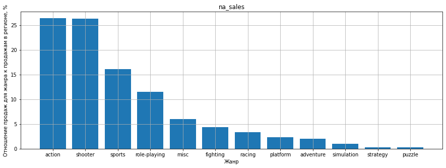

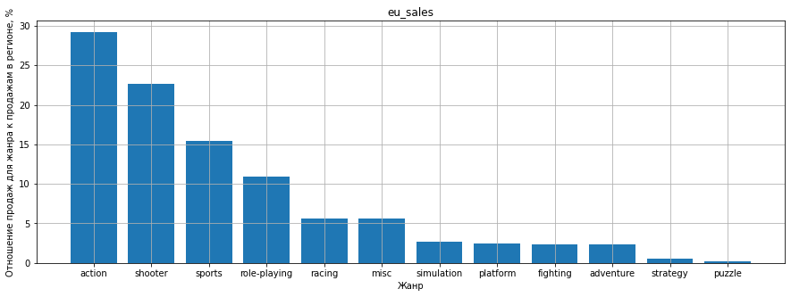

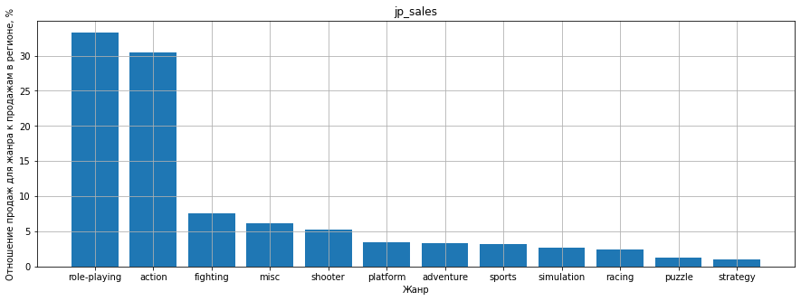

```python
for i in ['na_sales', 'eu_sales', 'jp_sales']:
    plt.figure(figsize=(15, 5))
    plt.bar(reg_gen_sales(df1, i, 'genre')['genre'], reg_gen_sales(df1, i, 'genre')['sale_ratio'])
    plt.grid()
    plt.xlabel('Жанр')
    plt.ylabel('Отношение продаж для жанра к продажам в регионе, %')
    plt.title(i)
    plt.show()
```

Таким образом, общие для всех регионов по популярности жанры: action, shooter, role-playing, misc, уникальные: sports и fighting. Выберем их, а также racing, platform и adventure, а остальные обозначим за other и построим круговую диаграмму.

```python
df1['na_top_genre']= list(map(lambda x: 'other' if x not in ['action', 'shooter', 'role-playing', 'misc', 'sports'] else x, df1['genre']))
```

```python
df1['eu_top_genre']= list(map(lambda x: 'other' if x not in ['action', 'shooter', 'role-playing', 'racing', 'sports'] else x, df1['genre']))
```

```python
df1['jp_top_genre']= list(map(lambda x: 'other' if x not in ['action', 'shooter', 'role-playing', 'fighting', 'misc'] else x, df1['genre']))
```

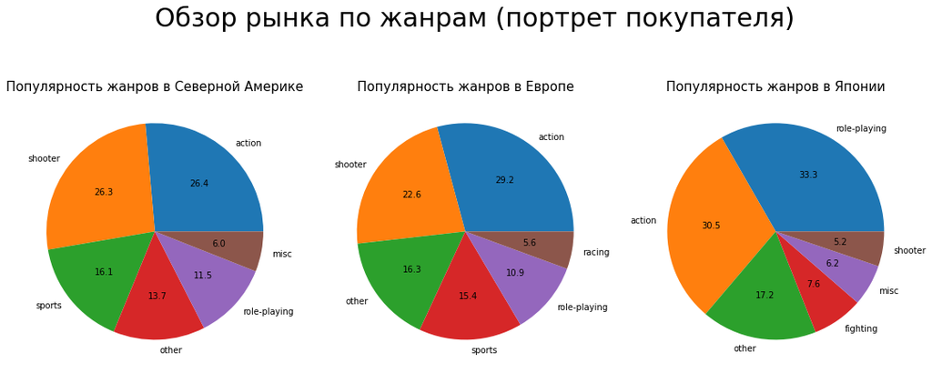

```python
plt.figure(figsize=(15, 7))

ax1 = plt.subplot(1, 3, 1)
ax1.pie(reg_sales(df1, 'na_sales', 'na_top_genre')['sale_ratio'], labels=reg_sales(df1, 'na_sales',
                                                                'na_top_genre')['na_top_genre'], autopct='%.1f');
ax1.set_title('Популярность жанров в Северной Америке', fontsize= 15)

ax2 = plt.subplot(1, 3, 2)
ax2.pie(reg_sales(df1, 'eu_sales', 'eu_top_genre')['sale_ratio'], labels=reg_sales(df1, 'eu_sales',
                                                                'eu_top_genre')['eu_top_genre'], autopct='%.1f');
ax2.set_title('Популярность жанров в Европе', fontsize= 15)

ax3 = plt.subplot(1, 3, 3)
ax3.pie(reg_sales(df1, 'jp_sales', 'jp_top_genre')['sale_ratio'], labels=reg_sales(df1, 'jp_sales',
                                                                'jp_top_genre')['jp_top_genre'], autopct='%.1f');
ax3.set_title('Популярность жанров в Японии', fontsize= 15)

plt.suptitle('Обзор рынка по жанрам (портрет покупателя)', fontsize=30)

plt.tight_layout()
plt.show()
```

- В странах Северной Америки самые популярные жанры (топ-5):  
  action (26.4%);  
  shooter (26.3%);  
  sports (16%);  
  role-playing (11.5%);  
  misc (6%).
- В странах Европы самые популярные жанры (топ-5):  
  action (29.2%);  
  shooter (22.6%);  
  sports (15.4%);  
  role-playing (10.9%);  
  racing/misc (5.6%).
- В Японии самые популярные жанры (топ-5):  
  role-playing (33.3%);  
  action (30.5%);  
  fighting (7.6%);  
  misc (6.2%);  
  shooter (5.2%).